# EXPLORATORY DATA ANALYSIS - SPORTS

GRIP @ The Sparks Foundation - Data Science and Business Analytics

## TASK 1: EXPLORATORY DATA ANALYSIS - SPORTS

Author : ADITYA RAJ

Objective : To perform "Exploratory Data Analysis" on the dataset 'Indian Premier League'

## IMPORTING THE REQUIRED LIBRARIES

```python
import pandas as pd
import numpy as np
import matplotlib.pyplot as plt
import seaborn as sns
%matplotlib inline
```

## LOADING AND READING DATASET

```python
matches_df = pd.read_csv("matches.csv")
matches_df.head(10)
```

|  | id | season | city | date | team1 | team2 | toss_winner | toss_decision | result | dl_applied | winner | win_by_runs | win_by_wickets | player_of_match | venue | umpire1 | umpire2 | umpire3 |
| --- | --- | --- | --- | --- | --- | --- | --- | --- | --- | --- | --- | --- | --- | --- | --- | --- | --- | --- |
| 0 | 1 | 2017 | Hyderabad | 2017-04-05 | Sunrisers Hyderabad | Royal Challengers Bangalore | Royal Challengers Bangalore | field | normal | 0 | Sunrisers Hyderabad | 35 | 0 | Yuvraj Singh | Rajiv Gandhi International Stadium, Uppal | AY Dandekar | NJ Llong | NaN |
| 1 | 2 | 2017 | Pune | 2017-04-06 | Mumbai Indians | Rising Pune Supergiant | Rising Pune Supergiant | field | normal | 0 | Rising Pune Supergiant | 0 | 7 | SPD Smith | Maharashtra Cricket Association Stadium | A Nand Kishore | S Ravi | NaN |
| 2 | 3 | 2017 | Rajkot | 2017-04-07 | Gujarat Lions | Kolkata Knight Riders | Kolkata Knight Riders | field | normal | 0 | Kolkata Knight Riders | 0 | 10 | CA Lynn | Saurashtra Cricket Association Stadium | Nitin Menon | CK Nandan | NaN |
| 3 | 4 | 2017 | Indore | 2017-04-08 | Rising Pune Supergiant | Kings XI Punjab | Kings XI Punjab | field | normal | 0 | Kings XI Punjab | 0 | 6 | GJ Maxwell | Holkar Cricket Stadium | AK Chaudhary | C Shamshuddin | NaN |
| 4 | 5 | 2017 | Bangalore | 2017-04-08 | Royal Challengers Bangalore | Delhi Daredevils | Royal Challengers Bangalore | bat | normal | 0 | Royal Challengers Bangalore | 15 | 0 | KM Jadhav | M Chinnaswamy Stadium | NaN | NaN | NaN |
| 5 | 6 | 2017 | Hyderabad | 2017-04-09 | Gujarat Lions | Sunrisers Hyderabad | Sunrisers Hyderabad | field | normal | 0 | Sunrisers Hyderabad | 0 | 9 | Rashid Khan | Rajiv Gandhi International Stadium, Uppal | A Deshmukh | NJ Llong | NaN |
| 6 | 7 | 2017 | Mumbai | 2017-04-09 | Kolkata Knight Riders | Mumbai Indians | Mumbai Indians | field | normal | 0 | Mumbai Indians | 0 | 4 | N Rana | Wankhede Stadium | Nitin Menon | CK Nandan | NaN |
| 7 | 8 | 2017 | Indore | 2017-04-10 | Royal Challengers Bangalore | Kings XI Punjab | Royal Challengers Bangalore | bat | normal | 0 | Kings XI Punjab | 0 | 8 | AR Patel | Holkar Cricket Stadium | AK Chaudhary | C Shamshuddin | NaN |
| 8 | 9 | 2017 | Pune | 2017-04-11 | Delhi Daredevils | Rising Pune Supergiant | Rising Pune Supergiant | field | normal | 0 | Delhi Daredevils | 97 | 0 | SV Samson | Maharashtra Cricket Association Stadium | AY Dandekar | S Ravi | NaN |
| 9 | 10 | 2017 | Mumbai | 2017-04-12 | Sunrisers Hyderabad | Mumbai Indians | Mumbai Indians | field | normal | 0 | Mumbai Indians | 0 | 4 | JJ Bumrah | Wankhede Stadium | Nitin Menon | CK Nandan | NaN |

## FEATURE EXPLORATION

```python
matches_df.shape
```

```
(636, 18)
```

```python
matches_df.info()
```

```
<class 'pandas.core.frame.DataFrame'>
RangeIndex: 636 entries, 0 to 635
Data columns (total 18 columns):
 #   Column           Non-Null Count  Dtype
---  ------           --------------  -----
 0   id               636 non-null    int64
 1   season           636 non-null    int64
 2   city             629 non-null    object
 3   date             636 non-null    object
 4   team1            636 non-null    object
 5   team2            636 non-null    object
 6   toss_winner      636 non-null    object
 7   toss_decision    636 non-null    object
 8   result           636 non-null    object
 9   dl_applied       636 non-null    int64
 10  winner           633 non-null    object
 11  win_by_runs      636 non-null    int64
 12  win_by_wickets   636 non-null    int64
 13  player_of_match  633 non-null    object
 14  venue            636 non-null    object
 15  umpire1          635 non-null    object
 16  umpire2          635 non-null    object
 17  umpire3          0 non-null      float64
dtypes: float64(1), int64(5), object(12)
memory usage: 89.6+ KB
```

```python
matches_df.describe()
```

|  | id | season | dl_applied | win_by_runs | win_by_wickets | umpire3 |
| --- | --- | --- | --- | --- | --- | --- |
| count | 636.000000 | 636.000000 | 636.000000 | 636.000000 | 636.000000 | 0.0 |
| mean | 318.500000 | 2012.490566 | 0.025157 | 13.682390 | 3.372642 | NaN |
| std | 183.741666 | 2.773026 | 0.156726 | 23.908877 | 3.420338 | NaN |
| min | 1.000000 | 2008.000000 | 0.000000 | 0.000000 | 0.000000 | NaN |
| 25% | 159.750000 | 2010.000000 | 0.000000 | 0.000000 | 0.000000 | NaN |
| 50% | 318.500000 | 2012.000000 | 0.000000 | 0.000000 | 4.000000 | NaN |
| 75% | 477.250000 | 2015.000000 | 0.000000 | 20.000000 | 7.000000 | NaN |
| max | 636.000000 | 2017.000000 | 1.000000 | 146.000000 | 10.000000 | NaN |

```python
matches_df.columns
```

```
Index(['id', 'season', 'city', 'date', 'team1', 'team2', 'toss_winner',
       'toss_decision', 'result', 'dl_applied', 'winner', 'win_by_runs',
       'win_by_wickets', 'player_of_match', 'venue', 'umpire1', 'umpire2',
       'umpire3'],
      dtype='object')
```

```python
matches_df.nunique()
```

```
id                 636
season              10
city                30
date               450
team1               14
team2               14
toss_winner         14
toss_decision        2
result               3
dl_applied           2
winner              14
win_by_runs         86
win_by_wickets      11
player_of_match    201
venue               35
umpire1             44
umpire2             45
umpire3              0
dtype: int64
```

```python
# checking for null values
matches_df.isnull().sum()
```

```
id                   0
season               0
city                 7
date                 0
team1                0
team2                0
toss_winner          0
toss_decision        0
result               0
dl_applied           0
winner               3
win_by_runs          0
win_by_wickets       0
player_of_match      3
venue                0
umpire1              1
umpire2              1
umpire3            636
dtype: int64
```

```python
#droping the umpire column to get the rid of null values
matches_df = matches_df.drop(['umpire3'],axis=1)
```

```python
len(matches_df['season'].unique())
```

```
10
```

```python
pd.concat([matches_df['team1'],matches_df['team2']]).unique()
```

```
array(['Sunrisers Hyderabad', 'Mumbai Indians', 'Gujarat Lions',
       'Rising Pune Supergiant', 'Royal Challengers Bangalore',
       'Kolkata Knight Riders', 'Delhi Daredevils', 'Kings XI Punjab',
       'Chennai Super Kings', 'Rajasthan Royals', 'Deccan Chargers',
       'Kochi Tuskers Kerala', 'Pune Warriors', 'Rising Pune Supergiants'],
      dtype=object)
```

## DATA VISUALIZATION

TEAMS THAT WON THE MATCH

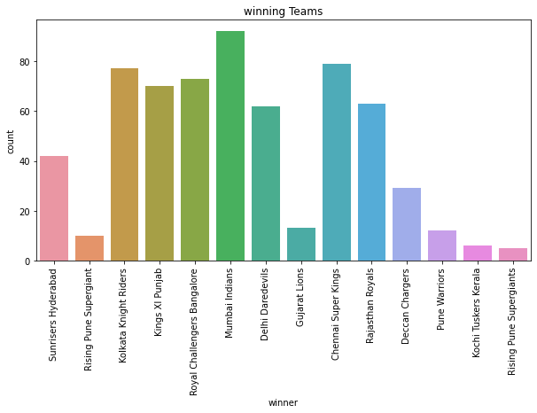

```python
plt.figure(figsize=(10,5))
sns.countplot(x = 'winner',data = matches_df)
plt.title('winning Teams')
plt.xticks(rotation = 90);
```

wins by Run

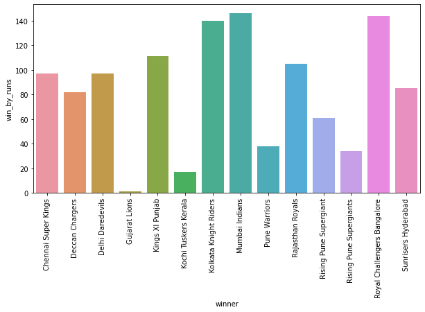

```python
win_max = matches_df.groupby(['winner'],as_index=False)['win_by_runs'].max()
plt.subplots(figsize=(10,5))
plt.xticks(rotation=90)
sns.barplot(win_max['winner'],win_max['win_by_runs'])
```

MAN OF THE MATCH WINNERS

```python
matches_df['player_of_match'].value_counts()[0:5]
```

```
CH Gayle          18
YK Pathan         16
DA Warner         15
AB de Villiers    15
RG Sharma         14
Name: player_of_match, dtype: int64
```

```
(array([0, 1, 2, 3, 4, 5, 6, 7, 8, 9]),
 [Text(0, 0, 'CH Gayle'),
```

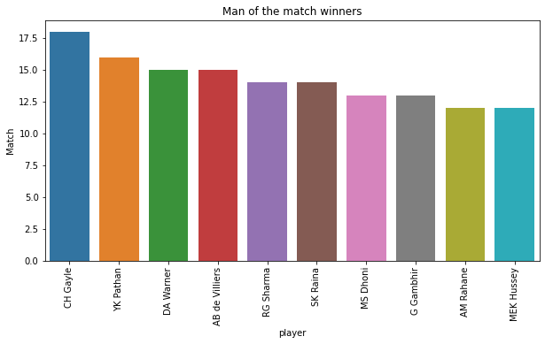

```python
plt.figure(figsize=(10,5))
sns.barplot(x=matches_df.player_of_match.value_counts()[:10].index,y=matches_df.player_of_match.value_counts()[:10])
plt.title('Man of the match winners')
plt.xlabel('player')
plt.ylabel('Match')
plt.xticks(rotation=90)
```

NUMBER OF MATCHES PER SEASON

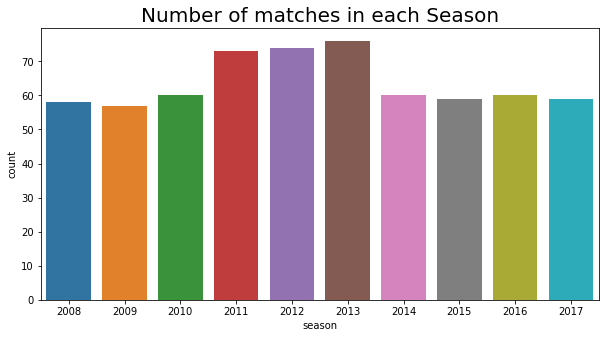

```python
plt.subplots(figsize=(10,5))
sns.countplot(x=matches_df['season'].sort_values())
plt.title('Number of matches in each Season',fontsize=20)
plt.show()
```

TOSS WINNERS

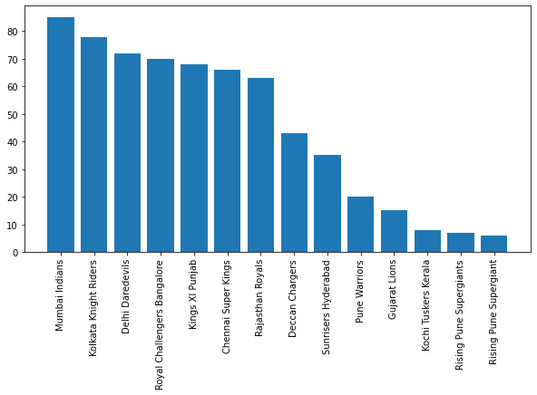

```python
plt.figure(figsize=(10,5))
plt.bar(list(matches_df['toss_winner'].value_counts().keys()),list(matches_df['toss_winner'].value_counts()))
plt.xticks(rotation=90)
plt.show()
```

COMPARISION ON TOSS DECISIONS

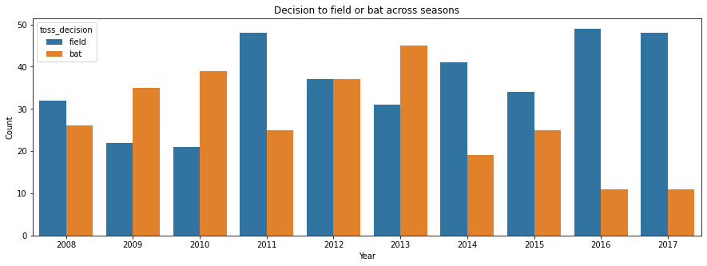

```python
plt.figure(figsize=(15,5))
sns.countplot(matches_df['season'].sort_values(),hue=matches_df['toss_decision'])
plt.title("Decision to field or bat across seasons")
plt.xlabel('Year')
plt.ylabel('Count')
plt.show()
```

WINNING OF A TEAM AFTER BATTING ON THE FIRST AND SECOND POSITIONS

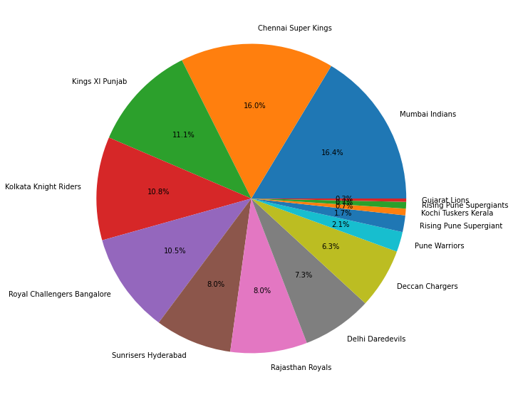

```python
batting_first = matches_df[matches_df['win_by_runs']!=0]
plt.figure(figsize=(10,10))
plt.pie(list(batting_first['winner'].value_counts()),labels=list(batting_first['winner'].value_counts().keys()),autopct='%0.1f%%')
plt.show()
```

```
(array([ 0,  1,  2,  3,  4,  5,  6,  7,  8,  9, 10, 11, 12, 13, 14, 15, 16,
        17, 18, 19, 20, 21, 22, 23, 24, 25, 26, 27, 28, 29, 30, 31, 32, 33,
        34]),
 [Text(0, 0, 'M Chinnaswamy Stadium'),
```

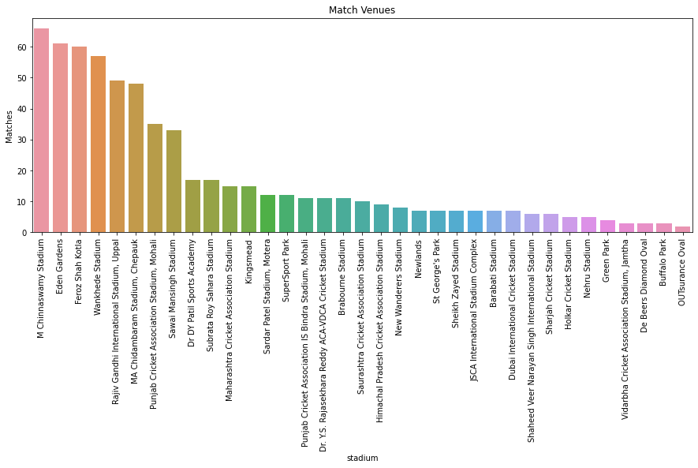

```python
plt.subplots(figsize=(15,5))
sns.countplot(x ='venue',data = matches_df,order = matches_df['venue'].value_counts().index)
plt.title('Match Venues')
plt.xlabel('stadium')
plt.ylabel('Matches')
plt.xticks(rotation = 90)
```

LOADING READING AND ANALYSING THE DELIVERIES DATASET

```python
deliveries_df = pd.read_csv('deliveries.csv')
deliveries_df
```

|  | match_id | inning | batting_team | bowling_team | over | ball | batsman | non_striker | bowler | is_super_over | ... | bye_runs | legbye_runs | noball_runs | penalty_runs | batsman_runs | extra_runs | total_runs | player_dismissed | dismissal_kind | fielder |
| --- | --- | --- | --- | --- | --- | --- | --- | --- | --- | --- | --- | --- | --- | --- | --- | --- | --- | --- | --- | --- | --- |
| 0 | 1 | 1 | Sunrisers Hyderabad | Royal Challengers Bangalore | 1 | 1 | DA Warner | S Dhawan | TS Mills | 0 | ... | 0 | 0 | 0 | 0 | 0 | 0 | 0 | NaN | NaN | NaN |
| 1 | 1 | 1 | Sunrisers Hyderabad | Royal Challengers Bangalore | 1 | 2 | DA Warner | S Dhawan | TS Mills | 0 | ... | 0 | 0 | 0 | 0 | 0 | 0 | 0 | NaN | NaN | NaN |
| 2 | 1 | 1 | Sunrisers Hyderabad | Royal Challengers Bangalore | 1 | 3 | DA Warner | S Dhawan | TS Mills | 0 | ... | 0 | 0 | 0 | 0 | 4 | 0 | 4 | NaN | NaN | NaN |
| 3 | 1 | 1 | Sunrisers Hyderabad | Royal Challengers Bangalore | 1 | 4 | DA Warner | S Dhawan | TS Mills | 0 | ... | 0 | 0 | 0 | 0 | 0 | 0 | 0 | NaN | NaN | NaN |
| 4 | 1 | 1 | Sunrisers Hyderabad | Royal Challengers Bangalore | 1 | 5 | DA Warner | S Dhawan | TS Mills | 0 | ... | 0 | 0 | 0 | 0 | 0 | 2 | 2 | NaN | NaN | NaN |
| ... | ... | ... | ... | ... | ... | ... | ... | ... | ... | ... | ... | ... | ... | ... | ... | ... | ... | ... | ... | ... | ... |
| 150455 | 636 | 2 | Royal Challengers Bangalore | Sunrisers Hyderabad | 20 | 2 | Sachin Baby | CJ Jordan | B Kumar | 0 | ... | 0 | 0 | 0 | 0 | 2 | 0 | 2 | NaN | NaN | NaN |
| 150456 | 636 | 2 | Royal Challengers Bangalore | Sunrisers Hyderabad | 20 | 3 | Sachin Baby | CJ Jordan | B Kumar | 0 | ... | 0 | 0 | 0 | 0 | 0 | 0 | 0 | CJ Jordan | run out | NV Ojha |
| 150457 | 636 | 2 | Royal Challengers Bangalore | Sunrisers Hyderabad | 20 | 4 | Iqbal Abdulla | Sachin Baby | B Kumar | 0 | ... | 0 | 1 | 0 | 0 | 0 | 1 | 1 | NaN | NaN | NaN |
| 150458 | 636 | 2 | Royal Challengers Bangalore | Sunrisers Hyderabad | 20 | 5 | Sachin Baby | Iqbal Abdulla | B Kumar | 0 | ... | 0 | 0 | 0 | 0 | 1 | 0 | 1 | NaN | NaN | NaN |
| 150459 | 636 | 2 | Royal Challengers Bangalore | Sunrisers Hyderabad | 20 | 6 | Iqbal Abdulla | Sachin Baby | B Kumar | 0 | ... | 0 | 0 | 0 | 0 | 4 | 0 | 4 | NaN | NaN | NaN |

150460 rows × 21 columns

```python
deliveries_df.shape
```

```
(150460, 21)
```

```python
deliveries_df.info()
```

```
<class 'pandas.core.frame.DataFrame'>
RangeIndex: 150460 entries, 0 to 150459
Data columns (total 21 columns):
 #   Column            Non-Null Count   Dtype
---  ------            --------------   -----
 0   match_id          150460 non-null  int64
 1   inning            150460 non-null  int64
 2   batting_team      150460 non-null  object
 3   bowling_team      150460 non-null  object
 4   over              150460 non-null  int64
 5   ball              150460 non-null  int64
 6   batsman           150460 non-null  object
 7   non_striker       150460 non-null  object
 8   bowler            150460 non-null  object
 9   is_super_over     150460 non-null  int64
 10  wide_runs         150460 non-null  int64
 11  bye_runs          150460 non-null  int64
 12  legbye_runs       150460 non-null  int64
 13  noball_runs       150460 non-null  int64
 14  penalty_runs      150460 non-null  int64
 15  batsman_runs      150460 non-null  int64
 16  extra_runs        150460 non-null  int64
 17  total_runs        150460 non-null  int64
 18  player_dismissed  7438 non-null    object
 19  dismissal_kind    7438 non-null    object
 20  fielder           5369 non-null    object
dtypes: int64(13), object(8)
memory usage: 24.1+ MB
```

```python
deliveries_df.describe()
```

|  | match_id | inning | over | ball | is_super_over | wide_runs | bye_runs | legbye_runs | noball_runs | penalty_runs | batsman_runs | extra_runs | total_runs |
| --- | --- | --- | --- | --- | --- | --- | --- | --- | --- | --- | --- | --- | --- |
| count | 150460.000000 | 150460.000000 | 150460.000000 | 150460.000000 | 150460.000000 | 150460.000000 | 150460.000000 | 150460.000000 | 150460.000000 | 150460.000000 | 150460.000000 | 150460.000000 | 150460.000000 |
| mean | 318.281317 | 1.482188 | 10.142649 | 3.616483 | 0.000538 | 0.037498 | 0.004885 | 0.022232 | 0.004340 | 0.000066 | 1.222445 | 0.069022 | 1.291466 |
| std | 182.955531 | 0.501768 | 5.674338 | 1.807698 | 0.023196 | 0.257398 | 0.114234 | 0.200104 | 0.072652 | 0.018229 | 1.594509 | 0.349667 | 1.583240 |
| min | 1.000000 | 1.000000 | 1.000000 | 1.000000 | 0.000000 | 0.000000 | 0.000000 | 0.000000 | 0.000000 | 0.000000 | 0.000000 | 0.000000 | 0.000000 |
| 25% | 161.000000 | 1.000000 | 5.000000 | 2.000000 | 0.000000 | 0.000000 | 0.000000 | 0.000000 | 0.000000 | 0.000000 | 0.000000 | 0.000000 | 0.000000 |
| 50% | 319.000000 | 1.000000 | 10.000000 | 4.000000 | 0.000000 | 0.000000 | 0.000000 | 0.000000 | 0.000000 | 0.000000 | 1.000000 | 0.000000 | 1.000000 |
| 75% | 476.000000 | 2.000000 | 15.000000 | 5.000000 | 0.000000 | 0.000000 | 0.000000 | 0.000000 | 0.000000 | 0.000000 | 1.000000 | 0.000000 | 1.000000 |
| max | 636.000000 | 4.000000 | 20.000000 | 9.000000 | 1.000000 | 5.000000 | 4.000000 | 5.000000 | 5.000000 | 5.000000 | 6.000000 | 7.000000 | 7.000000 |

```python
#Total matches where super over wasand wasn't played
deliveries_df['is_super_over'].value_counts()
```

```
0    150379
1        81
Name: is_super_over, dtype: int64
```

```python
#Total runs given by extra
sum(deliveries_df['extra_runs'])
```

```
10385
```

```python
#Total runs given by no balls
sum(deliveries_df['noball_runs'])
```

```
653
```

```python
#Total runs given on penality
sum(deliveries_df['penalty_runs'])
```

```
10
```

```python
#Total soft-dismissal of players over the years
sum(deliveries_df['player_dismissed'].value_counts())
```

```
7438
```

KINDS OF DISMISSAL

```
(array([0, 1, 2, 3, 4, 5, 6, 7, 8]),
 [Text(0, 0, 'caught'),
```

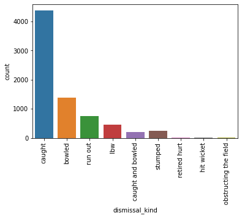

```python
sns.countplot(x=deliveries_df['dismissal_kind'],data=deliveries_df)
plt.xticks(rotation = 90)
```

# CONCLUSION

1)Total number of matches played was 636

3)Winning Teams

a)Mumbai Indians : first position b)Rising Pune Supergiants : last position

4)Win by Runs

5)Man of the match

6)Highest number of matches per season was on 2013

7)Mumbai Indians were the toss winners.

8)The only year with same toss for fielding and bating was on 2012

10)M chinnaswamy Stadium is the most popular match venue.

```python
THANKYOU!!
```